# 統計1

Tomoki Motegi

2024-09-26

## 準備編

まずは今回の統計で用いるR言語が動くようにソフトウェアやパッケージのインストールを行う。  
このようなプログラミング言語を使って説明する場合には、通常パッケージなどを使わずに直接開発すること（スクラッチ開発）をすることできちんとした理解をすることが好ましいが、本書の読者はプロのデータサイエンティストではない。  
このため本書では積極的にパッケージを活用していく方針としていく。  
**またうまくいかない場合は、出てきたエラーを直接ChatGPTなどの大規模言語モデルを用いた対話型AIサービスに入れることで解決策を得ることができるため、ぜひ活用していただきたい。**

### Rのインストール

まずGoogleの検索欄に`R`と打ち込んで以下のページをクリックする。

[figure not shown]

続いて真ん中の`downloa R`をクリックする。

[figure not shown]

CRAN Mirrorという変なページへ飛ばされるが、慌てずに下へスクロースしていく。

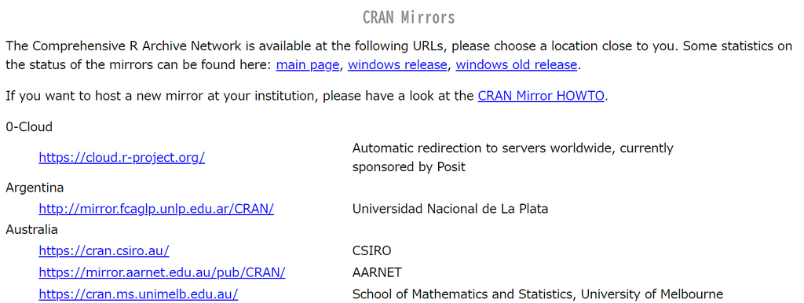

今自分が一番近い場所を選ぶ。  
通常であれば`Japan`の場所を選べばOK

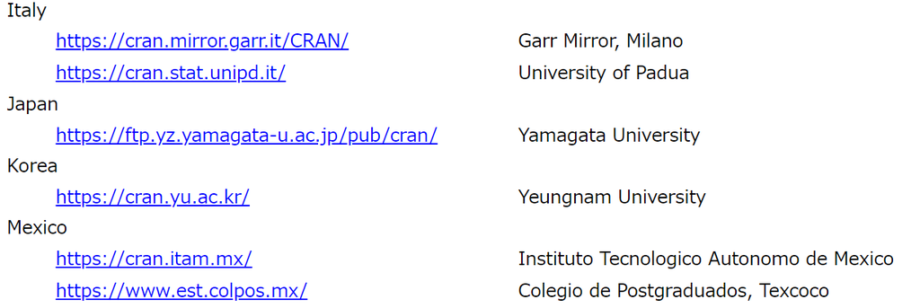

Download and Install Rのページに飛ぶので自身のOSにあったものを選んでクリック。

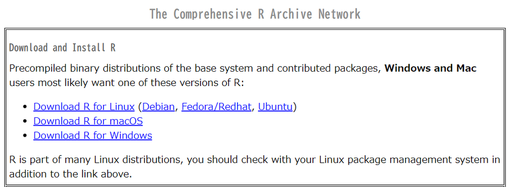

筆者はWindowsなので、R for Windowsのページに飛ぶことになる。  
ここで`base`をクリックしてRの基礎ソフトダウンロードページへ飛ぶ。

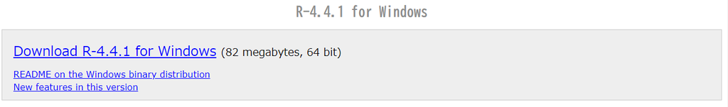

Download R-4.4.1 for Windowsをクリックしてダウンロード。  
これによってRのバージョン4.4.1がダウンロードされる。  
Rはどんどん開発が進んでおり、バージョンによっては入れられないパッケージなどがあるため、自身のバージョン情報を知っておく。  
後述するが、Rのコマンド上で確認できるため、メモを取る必要は無い。  
ダウンロードできたら、クリックしてインストールを行う。  
この際に日本語を選択することができる。  
初心者は心理的ハードルが下がるため、日本語にしておくほうが良い。

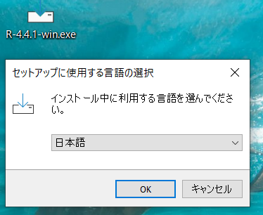

#### 個人的な余談：OSについて（WindowsとMac）

Rをインストールして動かすという一点を考えるならばWindowsの方が楽である。  
これは設計思想の違いであり、Windowsは過去に使えていたソフトを極力新しいOSでも動くように環境を整えており、反対にMacは不要となったものをどんどん削除して、自身が提供するベストな環境で動かすことを前提としている。このためMacでは古いソフトが削除されたために、Rの特定のパッケージが動かなくなるということをよく経験する。  
またユーザーの多さから、エラーが発生した際もWindows環境の方がネット上に解決策が提示されていることが多い。  
このため自身がWindowsユーザーであれば無理に別のパソコンを用意する必要は無い。

### Rstudioのインストール

RstudioはR言語専用の統合開発環境であり、必須のソフトではないが、操作が楽になるため、インストールすることをお勧めする。  
Rと同じようにGoogleの検索でRstudioと入力する。

[figure not shown]

ページが表示されたら下の方へスクロースする。

[figure not shown]

そうしたら2: Install RStudioの下にある`Download RStudio Desktop for windows`と書かれた青いバーをクリックする。

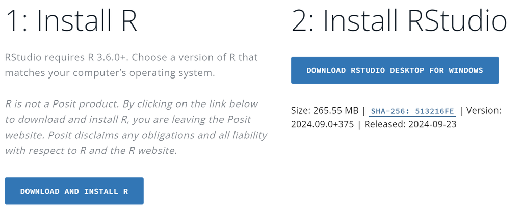

[figure not shown]

### Rstudioの起動

英語だがそれを上回るメリットがあるので、怯えずに使っていただきたい。  
まず環境を整える。メニューバーの下に4つ窓マークのWorkspace Panesがあるので、そこをクリックする。

[figure not shown]

するとRstudio上の画面をどのように分割するかが表示されるので、Show All PanesとConsole on Rightを選択する。  
（もしパソコンの画面が小さい方はConsole on Leftでもよい）

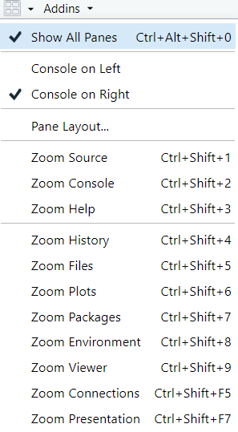

続いて一番左の+マークに白いドキュメントのボタンがあるのでそこをクリックする。

[figure not shown]

そうするとメニューが表示されるので、R Scriptをクリックする。

[figure not shown]

これでR言語を動かすことができるようになる。  
中身としては以下のようになっている。  
左上：スクリプトを書く場所（ソース）  
右上：スクリプトの実行を行う場所（コンソール）  
左下：現在の環境で読み込まれている情報（環境情報）  
右下：現在のディレクトリにおけるファイル情報など（ファイル情報）  
上部のタブを押すと他の機能が表示されるので、適宜切り替えてほしい。

[figure not shown]

文字が小さくて見づらい人はメニューバーのViewタブからZoom Inを押すと拡大できる

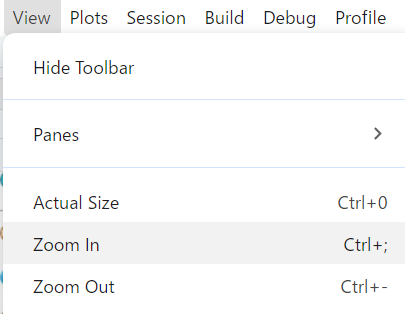

### Rstudioの超基本的な使い方

ここからR言語を使っていくが、プログラミングと身構えなくてよい。  
R言語とは突き詰めていってしまえば優秀な電卓である。  
なのでまずは電卓としての機能を使いながら、R言語へ慣れていく。  
尚、ここから何度もR言語と書くと面倒なため、Rと呼ぶことをにする。  
まずは以下のコマンドを左上のソース枠に記入してほしい。

```
2+3
4*5
6/7
```

その後一番上の行にカーソルを移してRunボタンかCtrl + Enterを押すとコンソール枠に結果が表示される。  
以降を繰り返していくと、各計算結果が表示される。

[figure not shown]

このように  
Rとは計算に特化し、かつ対話的に扱えるプログラミング言語であり、1行ずつ結果を得ることができる。  
このようなプログラミング言語をインタプリタ型と呼ぶ。  
以降は左右に表示した画像は見づらいため、コードを実行結果を以下のように示す。

```r
2+3
```

```
## [1] 5
```

```r
4*5
```

```
## [1] 20
```

```r
6/7
```

```
## [1] 0.8571429
```

### 解析で使うパッケージのインストール

R上は様々な計算が行えるが、これは様々な人が目的とする計算ができるようにプログラムを作っている。  
これを他の人が再利用できるようにしたものがパッケージである。  
パッケージのインストールには様々な方法があるが、2024年9月26日現在は以下の方法が推奨されている。  
まず、インストールを支援してくれるBiocManagerパッケージをインストールする。

```r
## BiocManagerパッケージが入っているか確認
if (!require("BiocManager", quietly = TRUE))
  #無い場合にはBiocManagerをインストール
  install.packages("BiocManager")
```

これが終わったのちに以下のコマンドを実行する。

```r
## インストールするパッケージの一覧を作成
install_files = c("MASS","ggplot2" ,"exactRankTests" ,"survival",
                  "survminer", "nnet", "ggdendro", "ComplexHeatmap", "circlize")
## このパッケージ一覧をインストールするコマンド
BiocManager::install(install_files, force = TRUE)
```

[output not shown]

[output not shown]

```
##  ソースパッケージ 'survival' をインストール中です
```

[output not shown]

[output not shown]

以下のようなポップアップ表示が出てきたらひとまず`はい(Y)`で良い。

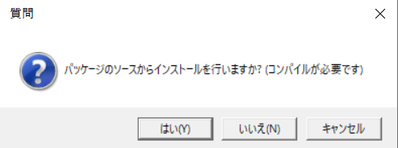

また既にパッケージがインストールされている場合は以下のように問われる場合があるが、コンソール枠側にひとまず`n`を入力しEnterを押しておく。

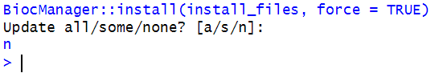

これは関連するパッケージをアップデートするかを聞かれているが、allを押すと時間がかかるため、省略している。  
そのままで動くことが多いため、エラーが出た際にアップデートを検討することが多い。  
続いて実際のパッケージが動くか検討する

```r
## パッケージを呼び出すコマンド
library(MASS)
```

```r
library(ggplot2)
library(exactRankTests)
library(survival)
library(survminer)
library(nnet)
library(ggdendro)
library(ComplexHeatmap)
library(circlize)
```

色々と警告が出てくる場合があるが、2回目実行してその警告が表示されなければ読み込めている。  
読み込んだパッケージに応じた計算が各種使えるようになり、その使い方は以下のコマンドで見ることができる。

```r
## survivalパッケージ生存時間解析を行うコマンド（=関数）survfitの使い方を表示するコマンド
?survfit
```

```
##  httpd ヘルプサーバーを起動...   完了
```